# Finding loop differences between HiChIP H3K27ac for EBNA3A On/Off

HiChIP results mapped via HiC-Pro and hichipper. 2 Reps per sample and also merged reps in parallel:

Help from: https://rpubs.com/caleblareau/diffloop_vignette

Load library first

```r
library(diffloop)
library(ggplot2)
library(GenomicRanges)
library(ggrepel)
library(DESeq2)
library(Repitools)
```

Now lets set up the environment and read in files The mango files are as such: EBNA3A_Off_merged.interactions.all.mango EBNA3A_On_merged.interactions.all.mango LIB035939_GEN00131730.interactions.all.mango LIB035939_GEN00131731.interactions.all.mango LIB035939_GEN00131732.interactions.all.mango LIB035939_GEN00131733.interactions.all.mango

Where 30, 31 are EBNA3A- Rep1,2 and 32, 33 are EBNA3A+ Rep1,2

This is what “full”" looks like:

```r
dim(full)
```

```
  anchors interactions samples colData rowData
1  191919      1395691       6       2       1
```

```r
head(full, 4)
```

```
An object of class "loops"
Slot "anchors":
GRanges object with 4 ranges and 0 metadata columns:
      seqnames        ranges strand
         <Rle>     <IRanges>  <Rle>
  [1]        1 711753-716177      *
  [2]        1 738766-741590      *
  [3]        1 749641-753559      *
  [4]        1 755513-757574      *
  -------
  seqinfo: 25 sequences from an unspecified genome; no seqlengths

Slot "interactions":
     left right
[1,]    1     2
[2,]    1     4
[3,]    1     5
[4,]    1     6

Slot "counts":
     EBNA3A_Off_Rep0 EBNA3A_Off_Rep1 EBNA3A_Off_Rep2 EBNA3A_On_Rep0 EBNA3A_On_Rep1 EBNA3A_On_Rep2
[1,]               0               0               0              2              1              1
[2,]               4               4               0              1              0              1
[3,]               2               1               1              1              1              0
[4,]               1               1               0              0              0              0

Slot "colData":
                sizeFactor     groups
EBNA3A_Off_Rep0  1.4282498 EBNA3A_Off
EBNA3A_Off_Rep1  0.7546509 EBNA3A_Off
EBNA3A_Off_Rep2  0.6085574 EBNA3A_Off
EBNA3A_On_Rep0   1.9611218  EBNA3A_On

Slot "rowData":
  loopWidth
1     26213
2     42578
3     48481
4     55556
```

Remove and loops that merged together from import and self loops

```r
full = subsetLoops(full, full@rowData$loopWidth >= 5000)
full = removeSelfLoops(full)
full_corrected = mangoCorrection(full, FDR = 0.01)
dim(full_corrected)
```

```
  anchors interactions samples colData rowData
1  186796       890807       6       2       3
```

Now lets filter the loops that have >= 5 PETs in one Rep but 0 in the other

```r
cm <- full_corrected@counts
EBNA3A_Off <- ((cm[,2]>=5 &cm[,3]==0)|(cm[,3]>=5&cm[,2]==0))
EBNA3A_On <- ((cm[,5]>=5 &cm[,6]==0)|(cm[,6]>=5&cm[,5]==0))
qc_filt <- subsetLoops(full_corrected, !(EBNA3A_Off | EBNA3A_On))
dim(qc_filt)
```

```
  anchors interactions samples colData rowData
1  186795       888246       6       2       3
```

Filtering complete, lets look at sample quality

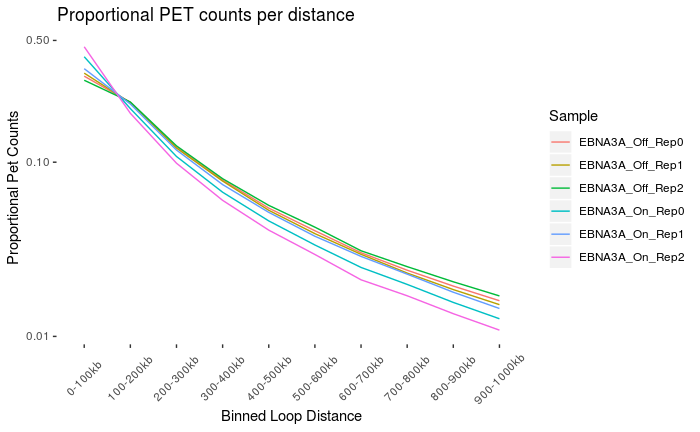

```r
p1 = loopDistancePlot(qc_filt)
p1
```

Looks great!

```r
loopMetrics(qc_filt)
```

```
       EBNA3A_Off_Rep0 EBNA3A_Off_Rep1 EBNA3A_Off_Rep2 EBNA3A_On_Rep0 EBNA3A_On_Rep1 EBNA3A_On_Rep2
unique          693328          391264          302064         845850         414584         431274
```

# Size Factor Adjustment

Take a look at the Size Factor:

```r
pcp1dat <- qc_filt
pcp1dat@colData$sizeFactor <- 1
pcp1 <- pcaPlot(pcp1dat) + geom_text_repel(aes(label=samples)) +
  scale_x_continuous(limits = c(-1000,1000)) + ggtitle("PC Plot with no Size Factor Correction") +
  scale_y_continuous(limits = c(-1000, 1000))
  theme(legend.position="none")
```

```
List of 1
 $ legend.position: chr "none"
 - attr(*, "class")= chr [1:2] "theme" "gg"
 - attr(*, "complete")= logi FALSE
 - attr(*, "validate")= logi TRUE
```

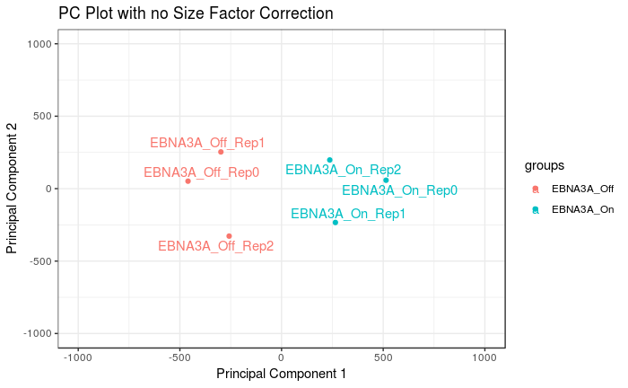

```r
pcp1
```

The samples fall pretty decently close to each other. This is before Size Factor adjustment. Lets adjust based on counts and try this again:

```r
pcp2 <-pcaPlot(qc_filt) + geom_text_repel(aes(label=samples)) +
    scale_x_continuous(limits = c(-1000, 1000)) + ggtitle("PC Plot with Size Factor Correction") +
    scale_y_continuous(limits = c(-1000, 1000))
    theme(legend.position="none")
```

```
List of 1
 $ legend.position: chr "none"
 - attr(*, "class")= chr [1:2] "theme" "gg"
 - attr(*, "complete")= logi FALSE
 - attr(*, "validate")= logi TRUE
```

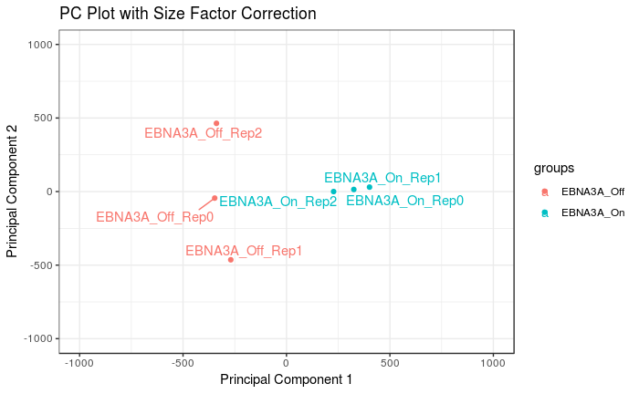

```r
pcp2
```

Size Correction works better for EBNA3A_On

# Differential Loop Calling

EBNA3A on vs off, lets look first at the biological replicates (2,3 and 5,6)

```r
km_filt = qc_filt[,c(2,3,5,6)]
dim(km_filt)
```

```
  anchors interactions samples colData rowData
1  186795       888246       4       2       3
```

1. Using edgeR to correct differential features

```r
km_res = quickAssoc(km_filt)
head(km_res@rowData)
```

```
  loopWidth    mango.FDR      mango.P     logFC   logCPM       LR    PValue       FDR
1     42578 0.0003151310 1.756028e-04 -1.906287 3.086680 2.059190 0.1512905 0.2946566
2    107535 0.0022085940 1.352850e-03 -2.388507 2.557228 1.478238 0.2240504 0.2946566
3    126432 0.0005511181 3.185800e-04  2.262121 2.556992 1.257311 0.2621607 0.2946566
4    134405 0.0003841094 2.170864e-04  2.262121 2.556992 1.257311 0.2621607 0.2946566
5    149171 0.0002194386 1.185836e-04  2.262121 2.556992 1.257311 0.2621607 0.2946566
6    200936 0.0000808402 3.871991e-05  2.262121 2.556992 1.257311 0.2621607 0.2946566
```

Filter loops on min size and number of counts per loop in samples In this case, we take loops > 2kb and having at least 1 read in 2 of the samples

```r
qcLoops = filterLoops(km_filt, width = 2000, nreplicates = 1, nsamples = 2)
dim(km_res)
```

```
  anchors interactions samples colData rowData
1  186795       888246       4       2       8
```

```r
dim(qcLoops)
```

```
  anchors interactions samples colData rowData
1   77435       142096       4       2       3
```

edgeR negative binomial test again

```r
qcLoops_edgeR = quickAssoc(qcLoops)
head(qcLoops_edgeR@rowData)
```

```
  loopWidth    mango.FDR      mango.P      logFC   logCPM          LR     PValue       FDR
1     42578 3.151310e-04 1.756028e-04 -1.8956579 4.131067 2.037903967 0.15342092 0.5527902
2      5903 0.000000e+00 0.000000e+00 -1.6777217 5.034006 3.797841463 0.05131870 0.4699223
3    136761 8.797332e-08 6.604250e-09 -0.1217049 3.755916 0.005343126 0.94172918 0.9457454
4    100690 9.244813e-06 1.924383e-06 -0.1246846 3.750707 0.005556667 0.94057828 0.9457454
5    207753 2.919371e-09 1.698003e-10 -3.2406320 3.756122 2.896686127 0.08876186 0.4699223
6     44582 3.416432e-03 2.123531e-03 -0.1324438 4.014801 0.009850351 0.92094062 0.9457454
```

Lets split out the edgeR differential loops, this may make it better! First, annotate the peaks based on enhancer, promoter and CTCF Enhancer: ChromHMM Annotated Enhancers +/- 2kb Promoter: TSS +/- 2kb CTCF: CTCF peaks +/- 500bp ** Need to remove chr for annotateLoops to work **

```r
enhancerbed = "wgEncodeBroadHmmGm12878HMMhg19_Enhancers.bed"
ctcfbed = "CTCFhuman.Rep.1.reg_peaks.narrowPeak"
enhancer = rmchr(padGRanges(bedToGRanges(enhancerbed), pad = 2000))
promoter <- rmchr(padGRanges(getHumanTSS(), pad = 2000)) # +/- 2kb
ctcf = rmchr(padGRanges(bedToGRanges(ctcfbed), pad = 500))
# Annotate the qcLoops object
km_anno <- annotateLoops(qcLoops_edgeR, enhancer = enhancer, promoter = promoter, ctcf = ctcf)
```

Distribution of loop types

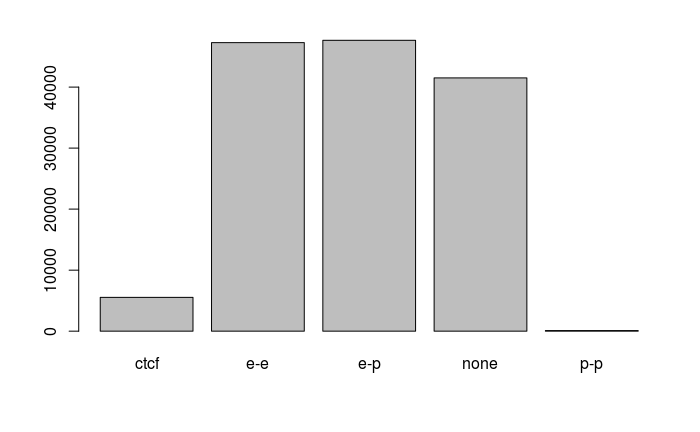

```r
barplot(table(km_anno@rowData$loop.type))
```

Repeat with 1.loops < 0.05 2.EP loops

```r
sig = 0.05
qcLoops_edgeR_sig = topLoops(km_anno, PValue = sig)
dim(qcLoops_edgeR_sig)
```

```
  anchors interactions samples colData rowData
1   13713         9937       4       2       9
```

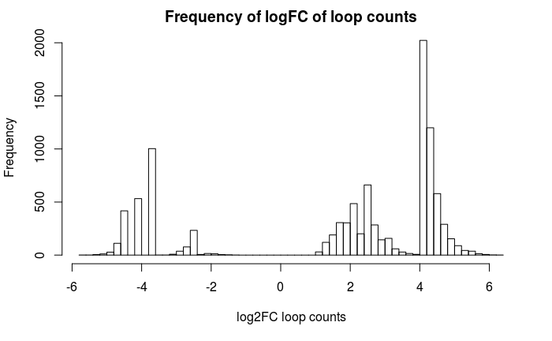

```r
hist(qcLoops_edgeR_sig@rowData$logFC, main = "Frequency of logFC of loop counts", xlab = "log2FC loop counts", breaks = 50)
```

Confirming summary plot

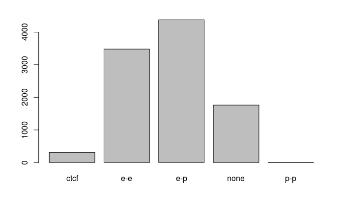

```r
barplot(table(topLoops(km_anno, PValue = sig)@rowData$loop.type))
```

Track only Enhancer-Promoter loops

First without p < 0.05 cutoff

```r
eploops = keepEPloops(km_anno, enhancer = enhancer, promoter = promoter)
dim(eploops)
```

```
  anchors interactions samples colData rowData
1   30593        47666       4       2      11
```

Summary plot confirming EP loops

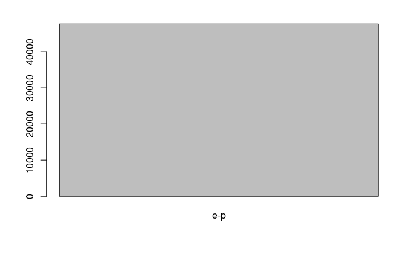

```r
barplot(table(eploops@rowData$loop.type))
```

Now with p < 0.05 cutoff and E-P

```r
sig = 0.05
eploops_sig = topLoops(eploops, PValue = sig)
dim(eploops)
```

```
  anchors interactions samples colData rowData
1   30593        47666       4       2      11
```

```r
dim(eploops_sig)
```

```
  anchors interactions samples colData rowData
1    6299         4379       4       2      11
```

Summary plot confirming EP loops p < 0.05

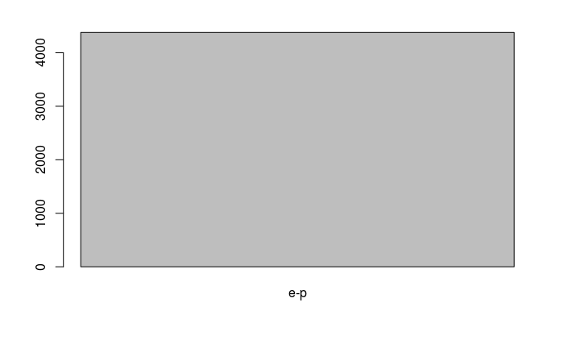

```r
barplot(table(eploops_sig@rowData$loop.type))
```

# Getting a data.frame back from a loops object using summary

```r
diffloop_df = summary(km_anno)
head(diffloop_df)
```

```
  chr_1 start_1  end_1 chr_2 start_2   end_2 EBNA3A_Off_Rep1 EBNA3A_Off_Rep2 EBNA3A_On_Rep1 EBNA3A_On_Rep2
1     1  711753 716177     1  755513  757574               4               0              0              1
2     1  755513 757574     1  760488  764405               3               9              3              1
3     1  755513 757574     1  888905  897704               0               1              1              0
4     1  760488 764405     1  855486  870787               1               0              0              1
5     1  806744 814721     1 1006971 1030001               1               1              0              0
6     1  817756 819352     1  855486  870787               2               0              1              1
  loopWidth    mango.FDR      mango.P      logFC   logCPM          LR     PValue       FDR loop.type
1     42578 3.151310e-04 1.756028e-04 -1.8956579 4.131067 2.037903967 0.15342092 0.5527902      none
2      5903 0.000000e+00 0.000000e+00 -1.6777217 5.034006 3.797841463 0.05131870 0.4699223      none
3    136761 8.797332e-08 6.604250e-09 -0.1217049 3.755916 0.005343126 0.94172918 0.9457454      none
4    100690 9.244813e-06 1.924383e-06 -0.1246846 3.750707 0.005556667 0.94057828 0.9457454       e-p
5    207753 2.919371e-09 1.698003e-10 -3.2406320 3.756122 2.896686127 0.08876186 0.4699223       e-p
6     44582 3.416432e-03 2.123531e-03 -0.1324438 4.014801 0.009850351 0.92094062 0.9457454       p-p
               region
1  chr1:686753-782574
2  chr1:730513-789405
3  chr1:730513-922704
4  chr1:735488-895787
5 chr1:781744-1055001
6  chr1:792756-895787
```

Now try to look at only pvalue < 0.05 and the interactions from ChIP-seq (this should be the same plot as above using topLoops!! Sanity Check!)

```r
sig = 0.05
diffloop_sig = diffloop_df[diffloop_df$PValue < 0.05,]
dim(diffloop_sig)
```

```
[1] 9937   20
```

```r
head(diffloop_sig)
```

```
    chr_1 start_1   end_1 chr_2 start_2   end_2 EBNA3A_Off_Rep1 EBNA3A_Off_Rep2 EBNA3A_On_Rep1 EBNA3A_On_Rep2
31      1  926529  929035     1  966139  971146               0               0              1              3
34      1  931306  941757     1  947693  950830               2               0             10              9
37      1  931306  941757     1  998171 1002802               0               0              1              4
38      1  931306  941757     1 1006971 1030001               3               2              0              0
91      1 1091969 1094481     1 1130962 1138481               0               0              2              2
118     1 1276105 1289967     1 1308647 1313931               3               1              0              0
    loopWidth    mango.FDR      mango.P     logFC   logCPM        LR      PValue       FDR loop.type
31      40860 4.850482e-03 3.046496e-03  4.011154 4.007999  4.818980 0.028147996 0.4699223       e-e
34      12730 0.000000e+00 0.000000e+00  2.961034 5.273474 10.312007 0.001321675 0.4699223       e-p
37      63955 1.298666e-04 6.640108e-05  4.312365 4.120863  5.932353 0.014865378 0.4699223       e-p
38      81954 7.210376e-05 3.389689e-05 -4.466206 4.137986  6.913216 0.008556097 0.4699223       e-p
91      41496 3.796739e-03 2.367674e-03  4.017781 4.011200  4.835086 0.027886253 0.4699223       e-e
118     28253 7.925888e-03 5.035575e-03 -4.158362 4.020222  5.607381 0.017884980 0.4699223       e-p
                  region
31    chr1:901529-996146
34    chr1:906306-975830
37   chr1:906306-1027802
38   chr1:906306-1055001
91  chr1:1066969-1163481
118 chr1:1251105-1338931
```

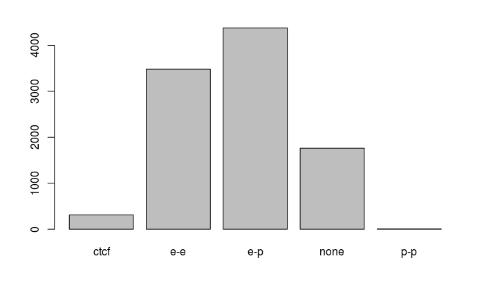

```r
barplot(table(diffloop_sig$loop.type))
```

Plot up and downregulated loops with subsetLoops and redo analysis on subset loops LogFC positive means upregulated in ON LogFC negative means upregaulted in OFF

```r
# subsetLoops(dlo, idxa)
up_ON = subsetLoops(qcLoops_edgeR_sig, qcLoops_edgeR_sig@rowData$logFC > 0)
down_ON = subsetLoops(qcLoops_edgeR_sig, qcLoops_edgeR_sig@rowData$logFC < 0)
```

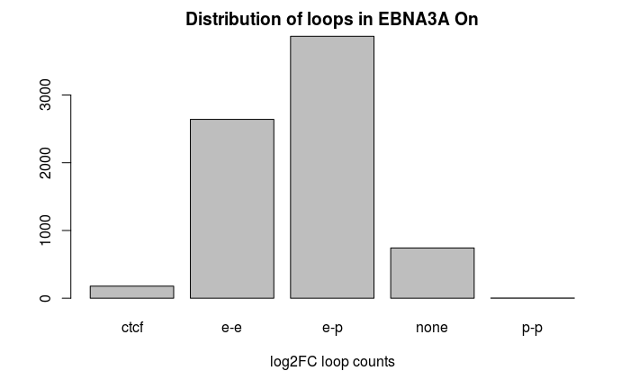

```r
barplot(table(up_ON@rowData$loop.type), main = "Distribution of loops in EBNA3A On", xlab = "log2FC loop counts")
```

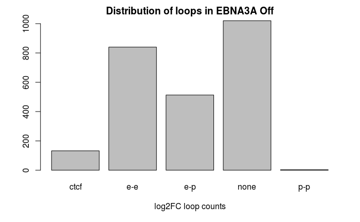

```r
barplot(table(down_ON@rowData$loop.type), main = "Distribution of loops in EBNA3A Off", xlab = "log2FC loop counts")
```

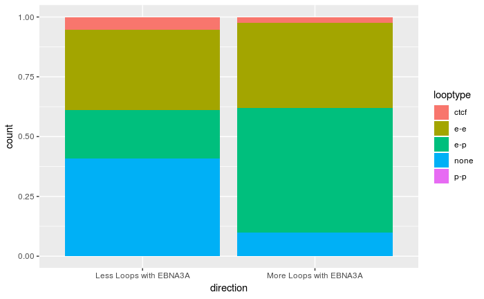

```r
up_freq = as.data.frame(up_ON@rowData$loop.type)
colnames(up_freq) = "looptype"
up_freq$direction = "More Loops with EBNA3A"
down_freq = as.data.frame(down_ON@rowData$loop.type)
colnames(down_freq) = "looptype"
down_freq$direction = "Less Loops with EBNA3A"
updown_freq = rbind(up_freq, down_freq)
ggplot(updown_freq, aes(x = direction, fill = looptype)) + geom_bar(position = "fill")
```

```r
paste("Up On")
```

```
[1] "Up On"
```

```r
table(up_ON@rowData$loop.type)
```

```
ctcf  e-e  e-p none  p-p
 178 2640 3866  742    3
```

```r
paste("Down On")
```

```
[1] "Down On"
```

```r
table(down_ON@rowData$loop.type)
```

```
ctcf  e-e  e-p none  p-p
 132  840  513 1020    3
```